# Дедуктивный метод в преподавательской и аналитической работе

## Что такое дедукция?

Дедукция – это логически правильный вывод из уже имеющегося знания или из уже имеющихся мыслей. Выводы, построенные с помощью дедукции, изучает наука логика. Натуральная дедукция в логике использует правила, которые близки тому, как рассуждает человек, поэтому она так и называется ‘’натуральная дедукция’’. Дедукция применяется в повседневной жизни, а также в преподавательской и аналитической работе.

[figure not shown]

## Пример дедуктивного рассуждения в логике

Дедукция известна со времен Аристотеля. Именно Аристотель рассматривал умозаключения с посылками и выводом.

Пример дедуктивного умозаключения:

- Все люди смертны.
- Сократ – человек.
- Следовательно, Сократ смертен.

Первые два суждения называются посылками, а последнее суждение – это вывод или следствие. В логике существуют определенные правила вывода, на основе которых строятся рассуждения. Эти правила нужны для того, чтобы приходить к истинному выводу, исходя из истинных посылок.

## Применение дедуктивных рассуждений в повседневной жизни

В рассказах Конан Дойла знаменитый сыщик Шерлок Холмс говорит о своём дедуктивном методе. Действительно, он рассматривает общую картину преступления, потом изучает детали. Дедукция — это рассуждение от общего знания к частному. То есть если мы имеем какое-то уже исходное знания, то мы дальше в процессе рассуждения приходим к неким выводам.

[figure not shown]

Представим, как бы рассуждал сыщик. Допустим мы находимся вне города и видим человека, который несёт рыбу.

Исходное знание – человек несет рыбу. Далее наше рассуждение выглядит так. Мы можем предположить, что, первое, — человек купил эту рыбу в магазине. Но магазина рядом нет, так что скорее всего он взял рыбу у кого-то или поймал ее сам. Если человек поймал рыбу сам, то тогда у него должно быть удочки с собой. Но удочки у него нет. Тогда, возможно, удочка осталась на берегу или у него вовсе не было удочки. Если у этого человека нет удочки вовсе, то он взял рыбу у кого-то. Сыщику достаточно будет посмотреть, нет ли на берегу удочки. Если она есть – то этот человек сам выловил рыбу. Если ее нет, то человек взял у кого-то эту рыбу. Это пример дедуктивного рассуждения: есть исходное общее знание, и далее мы рассматриваем частности и детали.

# Пример дедуктивного рассуждения при принятии решения

[figure not shown]

У Андрея сейчас уровень английского языка чуть ниже среднего. Он хочет достичь среднего уровня английского языка (B1) через 3 месяца. Рассмотрим рассуждения Андрея. Если я буду заниматься самостоятельно, то мне нужно будет самому искать учебные материалы, упражнения и выполнять задания без проверки преподавателя. Тогда я должен буду запланировать 3 часа в день на занятия английским, чтобы через 3 месяца достичь уровня B1.

Если я буду заниматься с преподавателем 2 раза в неделю, то тогда мне не нужно искать учебные материалы, упражнения, и преподаватель будет проверять мои задания. В этом случая я должен запланировать 2 часа в день на занятия английским языком, чтобы через 3 месяца достичь уровня B1.

**Заниматься самостоятельно или заниматься с преподавателем?**

Заниматься самостоятельно

Запланировать 3 часа на занятия английским языком в день. Я достигну уровня B1 через 3 месяца.

Заниматься с преподавателем

Запланировать 2 часа в день на занятия английским языком.

**Я достигну уровня B1 через 3 месяца.**

## Как дедуктивный метод помогает в жизни?

1. Цель определяется заранее.
2. Рассматриваем варианты того, как вы ее можете достигнуть.
3. На принятие решения не оказывают влияние эмоции.
4. На принятие решения не оказывают влияния советы третьих лиц.
5. Вы сами выбираете направление, которое вам позволит прийти к цели.
6. Вы можете выбрать наиболее экономичное (в денежном или время затратном плане) решение.

[figure not shown]

## Применение дедуктивного метода в преподавании и аналитической работе

Дедуктивный метод в преподавании основывается на объяснении с помощью правил. Вначале идет презентация правил, а потом следуют примеры употребления этих правил и упражнения на их отработку.

[figure not shown]

Примером дедуктивного обучения может быть следующая ситуация:  
Вы устроились на новое место работы. В первый рабочий день вы заметили, что ваши новые коллеги ставят плюсик напротив своей фамилии при входе в здание, берут пропуск, а после рабочего дня отдают пропуск на выходе из здания. После вы делаете тоже самое.

Итак, используя дедуктивный метод вы опираетесь изначально на некоторое правило. Например, в работе преподавателя иностранных языков применение этого метода будет следующим.

Когда начинается занятие по грамматике, после некоторого вступления, приветствия, преподаватель сначала объясняет правило использования той или иной грамматической конструкции, потом приводит примеры использования, и дает студентам упражнения на применение этого правила.

### Применение дедуктивного метода в когнитивно-поведенческой психологии

Рассмотрим пример применения дедуктивного метода в когнитивно-поведенческая психологии. Работа психотерапевта – аналитическая, специалист анализирует мыслительный процесс клиента, делает выводы. Необходимо отметить, что особенность этой терапии заключается в том, что клиент проводит большую самостоятельную работу, читает литературу и отрабатывает навыки.

[figure not shown]

Когда клиент приходит на первую сессию к психотерапевту, то ему не известны суть и особенности проведения консультаций у психотерапевта, работающего в этом направлении. Психотерапевт сначала объясняет специфику когнитивно-поведенческой терапии, рассказывает, как убеждения влияют на эмоции, а потом уже терапевт задает задание на применение и отработку определенных правил выявления когнитивных искажений.

Безусловно, как преподаватели, так и психотерапевты используют различные методы в своей работе. Каждый метод имеет свои особенности, преимущества и недостатки. Еще раз подчеркну, что в этой статье я рассматриваю приемы и методику именно дедуктивного метода.

Обзор дедуктивного подхода в преподавательской и аналитической работе был бы не полным, если не рассмотреть некоторые недостатки метода.

## Недостатки дедуктивного подхода

Рассмотрим на примере использования этого метода в преподавании иностранного языка:

- начинать урок с презентации грамматики может быть трудоемким и сложным для некоторых студентов, особенно начального уровня. Они могут не знать специфической терминологии для объяснения грамматики. Кроме того, они могут не понимать некоторые более простые грамматические конструкции;
- объяснение грамматики переводит центр внимания на преподавателя, тем самым уменьшая количество времени, которое можно использовать на взаимодействие студентов друг с другом. Тем самым, не уделяется основное время урока на отработку навыков общения и использование языка в речи;
- объяснение не так хорошо воспринимается, как другие формы презентации материала, как например наглядная демонстрация;
- такой подход может внушить студенту мысль, что знание языка – это просто знание некоторого набора правил.

## Преимущества дедуктивного метода

Дедуктивный метод имеет множество преимуществ, рассмотрим некоторые из них:

- он сразу достигает поставленной цели, и поэтому может быть экономным в плане финансовых затрат. Многие правила, в особенности правила грамматической формы, может быть просто и быстро объяснено, затем выявляться из примеров. Это дает больше времени на практику и применение правил;
- дедуктивный метод признает знания и зрелость студентов, а также роль когнитивных процессов в освоении языка;
- он оправдывает ожидания многих студентов от процесса обучения, в особенности тех студентов, у которых аналитический стиль изучения нового материала;
- он позволяет преподавателям иметь дело с различными особенностями языка в процессе урока вместо того, чтобы предполагать заранее те вопросы, которые могут возникнуть и готовиться к ним до урока.

## Источники

1. Thornbury S. How to Teach Grammar. Pearson Education Limited, 1999 Johan van Benthem, Hans van Ditmarsch, Jan van Eijck, Jan Jaspars. Logic in Action, 2016
2. Фотографии взяты из открытого источника www.pexels.com

### Всё что не вышло показать в статье

## $$f(k) = {n \choose k} p^{k} (1-p)^{n-k}$$

#### Код и таблицы

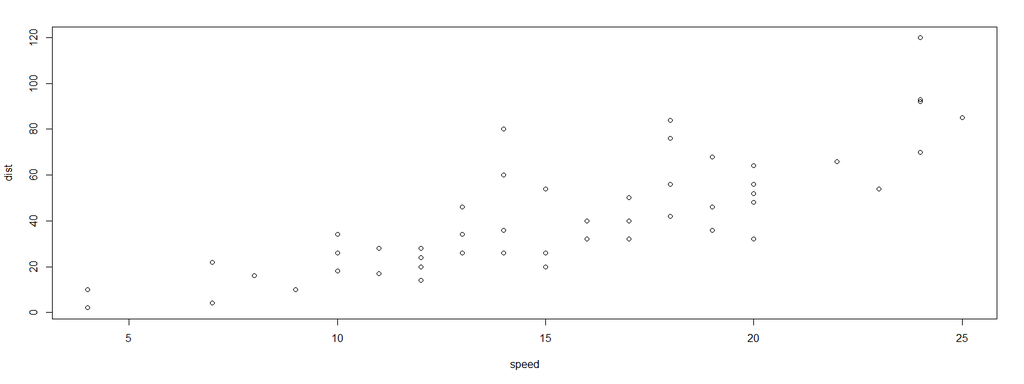

```r
plot(cars)
```

```r
library(knitr)
kable(mtcars[1:5,], caption="A knitr cable") # честно взято из https://rmarkdown.rstudio.com/lesson-7.html
```

A knitr cable

|  | mpg | cyl | disp | hp | drat | wt | qsec | vs | am | gear | carb |
| --- | --- | --- | --- | --- | --- | --- | --- | --- | --- | --- | --- |
| Mazda RX4 | 21.0 | 6 | 160 | 110 | 3.90 | 2.620 | 16.46 | 0 | 1 | 4 | 4 |
| Mazda RX4 Wag | 21.0 | 6 | 160 | 110 | 3.90 | 2.875 | 17.02 | 0 | 1 | 4 | 4 |
| Datsun 710 | 22.8 | 4 | 108 | 93 | 3.85 | 2.320 | 18.61 | 1 | 1 | 4 | 1 |
| Hornet 4 Drive | 21.4 | 6 | 258 | 110 | 3.08 | 3.215 | 19.44 | 1 | 0 | 3 | 1 |
| Hornet Sportabout | 18.7 | 8 | 360 | 175 | 3.15 | 3.440 | 17.02 | 0 | 0 | 3 | 2 |